# Building a Yelp Recommender System - Final Project

Author

Tobias Starling, Deanna Hu, Nabeel Vakil, Derek Gong - PSTAT 134

# Introduction

## Project Scope

The goal of our group was to implement a Yelp recommender system that would return ten restaurant recommendations when given either a user or restaurant. We built a collaborative filtering recommendation system using a K-Nearest Neighbors model with cosine similarity and content-based filtering. We also integrated a Natural Language Processing element to analyze the general sentiment of written reviews and further refine our model.

## Data Cleaning

We got our data set from an open-source Yelp API data set that contained over 7 million data points from all types of businesses across the US. https://business.yelp.com/data/resources/open-dataset/

### Upload Files

Loading the necessary libraries:

```r
library(httr)
library(jsonlite)
library(tidyverse)
library(reticulate)
library(ggplot2)
library(wordcloud)
library(naniar)
library(tidymodels)
library(stringr)
library(fs)
library(tidytext)
library(kableExtra)
```

```r
businesses <- stream_in(file("Yelp JSON/yelp_dataset/yelp_academic_dataset_business.json"))
reviews <- stream_in(file("Yelp JSON/yelp_dataset/yelp_academic_dataset_review.json"))
tips <- stream_in(file("Yelp JSON/yelp_dataset/yelp_academic_dataset_tip.json"))
users <- stream_in(file("Yelp JSON/yelp_dataset/yelp_academic_dataset_user.json"))
```

### Variables of Interest

The variables of interest that we pulled from the dataset include: price, location, type of restaurant, and number of stars. Luckily, the downloaded dataset didn’t contain any missing information in our categories of interest. It only contained missing data in categories irrelevant to us, such as whether the restaurant accepted Cryptocurrency or not, so we didn’t have to create any processes to handle missing data. We also took into account another variable called weighted sentiment. This is where we implemented Natural Language Processing on written reviews to assess the service, atmosphere, and quality of food associated with recommended restaurants.

Creating a list of business IDs that are restaurants/eateries:

```r
# Cleaning businesses.json
# Select columns: business_id, name, city, state, postal code, stars, categories, attributes
head(businesses)
businesses1 <- businesses %>%
  select(business_id, name, address, city, state, postal_code, stars, review_count, categories)
restaurants_only <- businesses1 %>%
  filter(!duplicated(business_id)) %>% #remove duplicates
  filter(grepl(c("Restaurants|Food|Breweries|Fast Food|Pubs|Burgers|Korean|Vietnamese|Food Trucks|Diners|Delis|Bakeries|Gastropubs|Cafes|Steakhouses|Bars|Pizza|Sandwiches"), categories)) %>%
  filter(stars >= 2.5)
cali_only <- restaurants_only %>%
  filter(grepl("CA", state))

# Cleaning reviews.json
head(reviews)
restaurant_reviews <- reviews %>%
  inner_join(restaurants_only, by = join_by(business_id))
restaurant_reviews <- restaurant_reviews %>%
  select(-c(address, city, state, postal_code, stars.y, categories))

# Cleaning tips.json
head(tips)
restaurant_tips <- tips %>%
  inner_join(restaurants_only, by = join_by(business_id))
restaurant_tips <- restaurant_tips %>%
#  select(-c(X.1, X, address, city, state, postal_code, stars, review_count, categories))
  select(-c(address, city, state, postal_code, stars, review_count, categories))

# Cleaning users.json
head(users)
users1 <- users %>%
  filter(!duplicated(user_id)) %>% #remove duplicate user values if any
  select(c(user_id, review_count, yelping_since, useful, funny, cool, fans, average_stars))
# Sort highest to lowest
users_cleaned <- users1 %>%
  filter(review_count > 0) %>% #delete users with no reviews
  arrange(desc(review_count))
#users_cleaned <- users_cleaned %>%
#  select(-c(X, X.1))
```

Exporting the list of business IDs with their data, and selecting reviews for those business IDs (also exporting into csv files):

```r
write.csv(restaurants_only, file = "yelp_restaurants.csv")
write.csv(restaurant_reviews, file = "yelp_restaurant_reviews.csv")
write.csv(users_cleaned, file = "users_cleaned.csv")
write.csv(restaurant_tips, file = "tips_cleaned.csv")
```

Loading pre-saved CSV files instead of the full JSON files:

```r
restaurants_only <- read.csv(file = "yelp_restaurants.csv")
restaurant_reviews <- read.csv(file = "yelp_restaurant_reviews.csv")
restaurant_tips <- read.csv(file = "tips_cleaned.csv")
users_cleaned <- read.csv(file = "users_cleaned.csv")
```

Viewing cleaned files:

```r
head(restaurants_only)
```

```
  X            business_id                     name           address
1 1 MTSW4McQd7CbVtyjqoe9mw       St Honore Pastries       935 Race St
2 2 mWMc6_wTdE0EUBKIGXDVfA Perkiomen Valley Brewery     101 Walnut St
3 3 k0hlBqXX-Bt0vf1op7Jr1w    Tsevi's Pub And Grill 8025 Mackenzie Rd
4 4 eEOYSgkmpB90uNA7lDOMRA    Vietnamese Food Truck
5 5 il_Ro8jwPlHresjw9EGmBg                  Denny's      8901 US 31 S
6 6 0bPLkL0QhhPO5kt1_EXmNQ     Zio's Italian Market     2575 E Bay Dr
          city state postal_code stars review_count
1 Philadelphia    PA       19107   4.0           80
2   Green Lane    PA       18054   4.5           13
3       Affton    MO       63123   3.0           19
4    Tampa Bay    FL       33602   4.0           10
5 Indianapolis    IN       46227   2.5           28
6        Largo    FL       33771   4.5          100
                                                                  categories
1                      Restaurants, Food, Bubble Tea, Coffee & Tea, Bakeries
2                                                  Brewpubs, Breweries, Food
3 Pubs, Restaurants, Italian, Bars, American (Traditional), Nightlife, Greek
4                                 Vietnamese, Food, Restaurants, Food Trucks
5            American (Traditional), Restaurants, Diners, Breakfast & Brunch
6                                Food, Delis, Italian, Bakeries, Restaurants
```

```r
head(restaurant_reviews)
```

```
  X              review_id                user_id            business_id
1 1 KU_O5udG6zpxOg-VcAEodg mh_-eMZ6K5RLWhZyISBhwA XQfwVwDr-v0ZS3_CbbE5Xw
2 2 saUsX_uimxRlCVr67Z4Jig 8g_iMtfSiwikVnbP2etR0A YjUWPpI6HXG530lwP-fb2A
3 3 AqPFMleE6RsU23_auESxiA _7bHUi9Uuf5__HHc_Q8guQ kxX2SOes4o-D3ZQBkiMRfA
4 4 Sx8TMOWLNuJBWer-0pcmoA bcjbaE6dDog4jkNY91ncLQ e4Vwtrqf-wpJfwesgvdgxQ
5 5 JrIxlS1TzJ-iCu79ul40cQ eUta8W_HdHMXPzLBBZhL1A 04UD14gamNjLY0IDYVhHJg
6 6 _ZeMknuYdlQcUqng_Im3yg yfFzsLmaWF2d4Sr0UNbBgg LHSTtnW3YHCeUkRDGyJOyw
  stars.x useful funny cool
1       3      0     0    0
2       3      0     0    0
3       5      1     0    1
4       4      1     0    1
5       1      1     2    1
6       5      2     0    0
                                                                                                                                                                                                                                                                                                            …
1                    If you decide to eat here, just be aware it is going to take about 2 hours from beginning to end. We have tried it multiple times, because I want to like it! I have been to it's other locations in NJ and never had a bad experience. \n\nThe food is good, but it takes a very long …
2                                                                                                                                                                                                    Family diner. Had the buffet. Eclectic assortment: a large chicken leg, fried jalapeño, tamale, two rol…
3                                                                                                                                                                                                                                                                                                    Wow!  Y…
4 Cute interior and owner (?) gave us tour of upcoming patio/rooftop area which will be great on beautiful days like today. Cheese curds were very good and very filling. Really like that sandwiches come w salad, esp after eating too many curds! Had the onion, gruyere, tomato sandwich. Wasn't too muc…
5                                                                                                                                                                                                  I am a long term frequent customer of this establishment. I just went in to order take out (3 apps) and w…
6                                                                                                                                                                                                                                                                                                           …
                 date                         name review_count
1 2018-07-07 22:09:11 Turning Point of North Wales          169
2 2014-02-05 20:30:30            Kettle Restaurant           47
3 2015-01-04 00:01:03                        Zaika          181
4 2017-01-14 20:54:15                         Melt           32
5 2015-09-23 23:10:31                     Dmitri's          273
6 2015-08-07 02:29:16              Fries Rebellion          103
```

```r
head(restaurant_tips)
```

```
  X                user_id            business_id
1 1 NBN4MgHP9D3cw--SnauTkA QoezRbYQncpRqyrLH6Iqjg
2 2 -copOvldyKh1qr-vzkDEvw MYoRNLb5chwjQe3c_k37Gg
3 3 FjMQVZjSqY8syIO-53KFKw hV-bABTK-glh5wj31ps_Jw
4 4 ld0AperBXk1h6UbqmM80zw _uN0OudeJ3Zl_tf6nxg5ww
5 5 YVBB9g23nuVJ0u44zK0pSA jtri188kuhe_AuEOJ51U_A
6 6 VL12EhEdT4OWqGq0nIqkzw xODBZmX4EmlVvbqtKN7YKg
                                                                              text
1                        They have lots of good deserts and tasty cuban sandwiches
2                                           It's open even when you think it isn't
3                                                        Very decent fried chicken
4                                           Appetizers.. platter special for lunch
5 This is probably the best place in the cool Springs area to watch a game and eat
6                                                                            Tacos
                 date compliment_count                        name
1 2013-02-05 18:35:10                0   La Segunda Central Bakery
2 2013-08-18 00:56:08                0 Sean Thorntons Public House
3 2017-06-27 23:05:38                0          Wok Out Restaurant
4 2012-10-06 19:43:09                0                Siam Cuisine
5 2016-11-22 22:14:58                0       Buffalo Wings & Rings
6 2012-07-27 01:48:24                0                  Surf Shack
```

```r
head(users_cleaned)
```

```
  X                user_id review_count       yelping_since useful  funny
1 1 Hi10sGSZNxQH3NLyWSZ1oA        17473 2009-05-26 11:33:58 206296 185823
2 2 8k3aO-mPeyhbR5HUucA5aA        16978 2007-12-08 14:56:45 152979  84992
3 3 hWDybu_KvYLSdEFzGrniTw        16567 2009-03-08 21:47:44 173089  98459
4 4 RtGqdDBvvBCjcu5dUqwfzA        12868 2010-10-17 06:35:06  11109   3747
5 5 P5bUL3Engv-2z6kKohB6qQ         9941 2006-05-31 21:27:42  27549  10772
6 6 nmdkHL2JKFx55T3nq5VziA         8363 2011-11-29 15:50:53  57242  28960
    cool fans average_stars
1 195814 3493          3.77
2 125516 1462          3.35
3 144849  867          3.67
4   3292  300          3.87
5  21375  825          3.81
6  46435  921          3.75
```

Checking for any missing data:

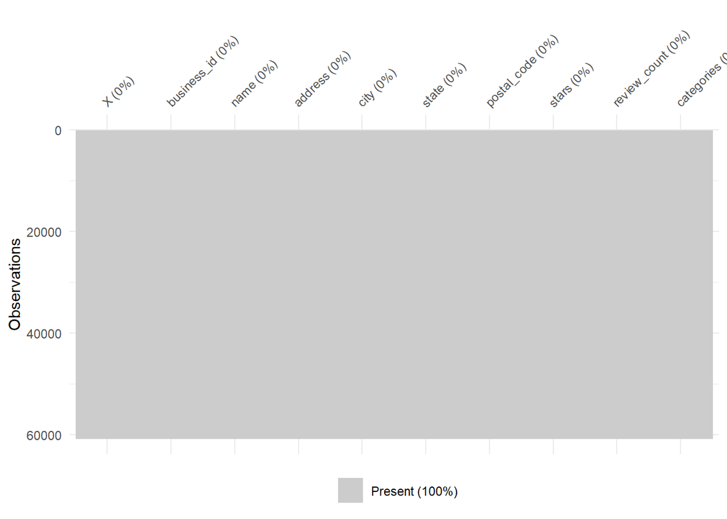

```r
# Checking missing values
restaurants_only %>%
  vis_miss()
```

As seen, there are no missing values in any column (except for when considering attributes and hours for the restaurant, which are not relevant to us).

## Data Visualization

### User data visualizations

```r
head(users_cleaned)
```

```
  X                user_id review_count       yelping_since useful  funny
1 1 Hi10sGSZNxQH3NLyWSZ1oA        17473 2009-05-26 11:33:58 206296 185823
2 2 8k3aO-mPeyhbR5HUucA5aA        16978 2007-12-08 14:56:45 152979  84992
3 3 hWDybu_KvYLSdEFzGrniTw        16567 2009-03-08 21:47:44 173089  98459
4 4 RtGqdDBvvBCjcu5dUqwfzA        12868 2010-10-17 06:35:06  11109   3747
5 5 P5bUL3Engv-2z6kKohB6qQ         9941 2006-05-31 21:27:42  27549  10772
6 6 nmdkHL2JKFx55T3nq5VziA         8363 2011-11-29 15:50:53  57242  28960
    cool fans average_stars
1 195814 3493          3.77
2 125516 1462          3.35
3 144849  867          3.67
4   3292  300          3.87
5  21375  825          3.81
6  46435  921          3.75
```

```r
users_cleaned <- users_cleaned %>%
  mutate(year_created = as.numeric(substr(yelping_since, 1, 4))) %>%
  mutate(review_count_group = cut(review_count,
                breaks = c(-Inf, 10, 50, 100, 500, 1000, 2000, 5000, 10000, Inf),
                labels = c("<10", "10-50", "50-100", "100-500", "500-1000", "1000-2000", "2000-5000", "5000-10000", "10000+"),
                right = FALSE)) %>%
mutate(useful_count_group = cut(useful,
                breaks = c(-Inf, 10, 50, 100, 500, 1000, 2000, 5000, 10000, Inf),
                labels = c("<10", "10-50", "50-100", "100-500", "500-1000", "1000-2000", "2000-5000", "5000-10000", "10000+"),
                right = FALSE)) %>%
mutate(funny_count_group = cut(funny,
                breaks = c(-Inf, 10, 50, 100, 500, 1000, 2000, 5000, 10000, Inf),
                labels = c("<10", "10-50", "50-100", "100-500", "500-1000", "1000-2000", "2000-5000", "5000-10000", "10000+"),
                right = FALSE))
```

To more easily visualize the distribution of data in this dataset, we have split the data into ranges. When initially graphing the data, the values were largely skewed right and hard to distinguish meaning from.

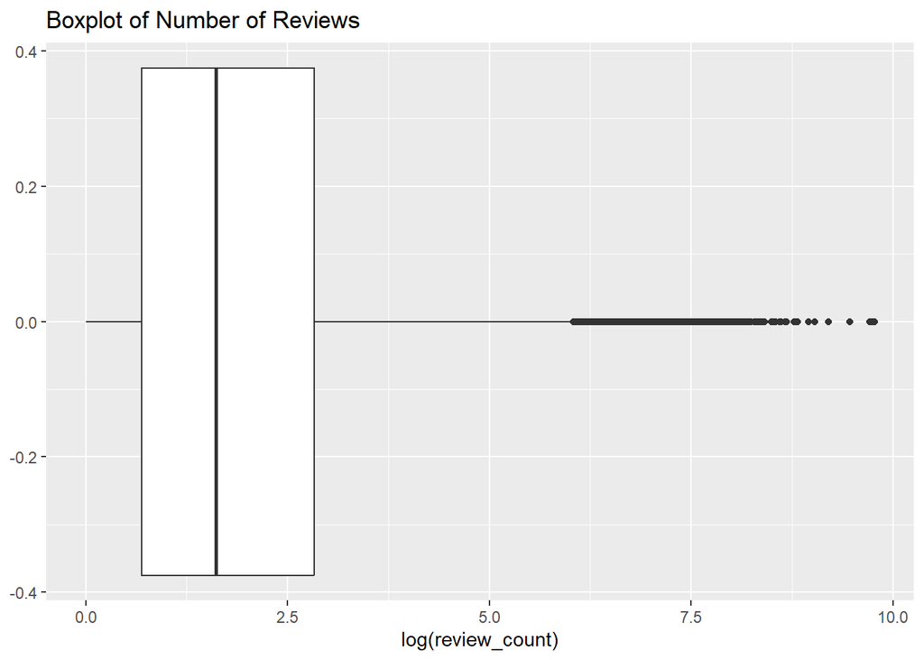

```r
# Distribution of Number of Reviews
ggplot(users_cleaned, aes(x=log(review_count))) +
  geom_boxplot() +
  labs(title="Boxplot of Number of Reviews")
```

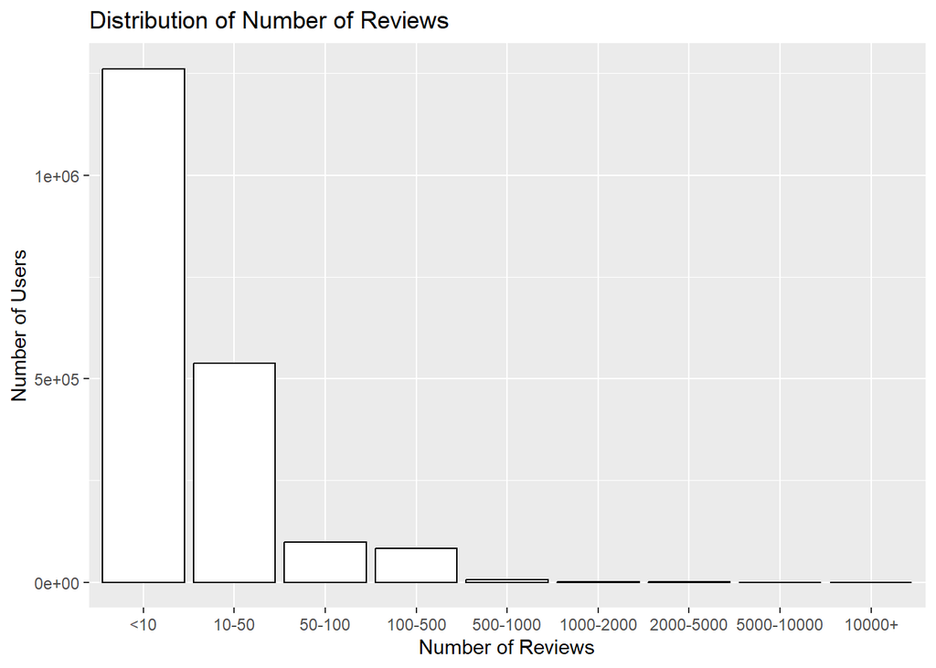

```r
ggplot(users_cleaned, aes(x=review_count_group)) +
  geom_bar(color="black", fill="white") +
  labs(title="Distribution of Number of Reviews", x="Number of Reviews", y="Number of Users")
```

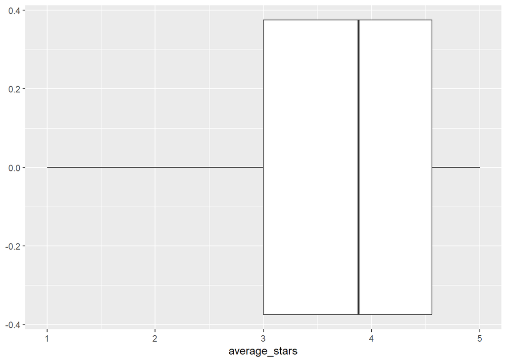

```r
# Boxplot of star distributions
ggplot(users_cleaned, aes(x=average_stars)) +
  geom_boxplot()
```

This graph shows the distribution of stars that users rate on average.

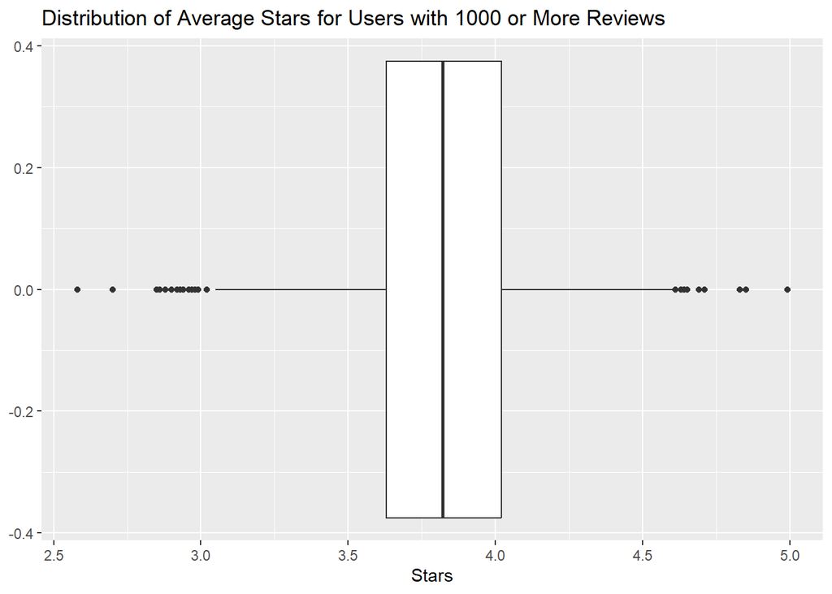

```r
# Star distribution of users with 500+ reviews
users_1000_plus <- users_cleaned %>%
  filter(review_count >= 1000)
ggplot(users_1000_plus, aes(x=average_stars)) +
  geom_boxplot() +
  labs(title="Distribution of Average Stars for Users with 1000 or More Reviews", x="Stars")
```

Users that have reviewed more restaurants are more likely to have a more nuanced average rating than users that have only reviewed a few—say only their favorite restaurants, or restaurants where service was horrible.

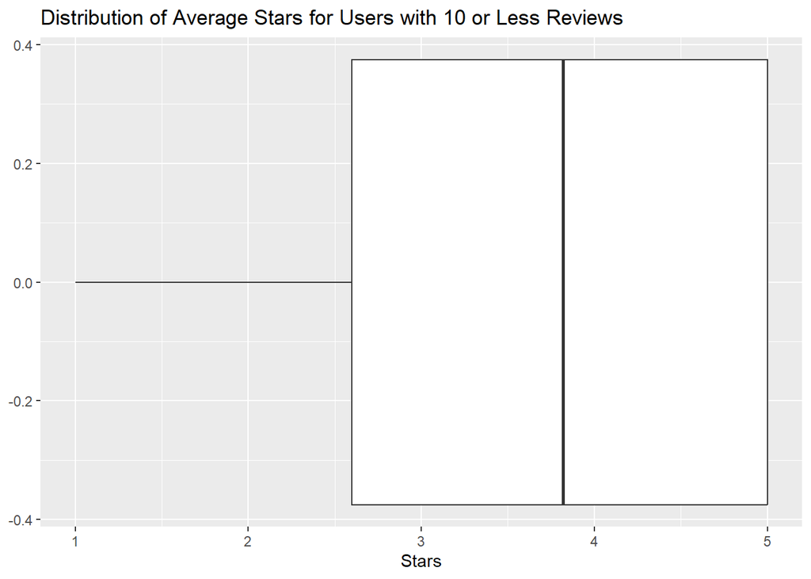

```r
# Star distribution of users with <=50 reviews
users_less_than_10 <- users_cleaned %>%
  filter(review_count <= 10)
ggplot(users_less_than_10, aes(x=average_stars)) +
  geom_boxplot() +
  labs(title="Distribution of Average Stars for Users with 10 or Less Reviews", x="Stars")
```

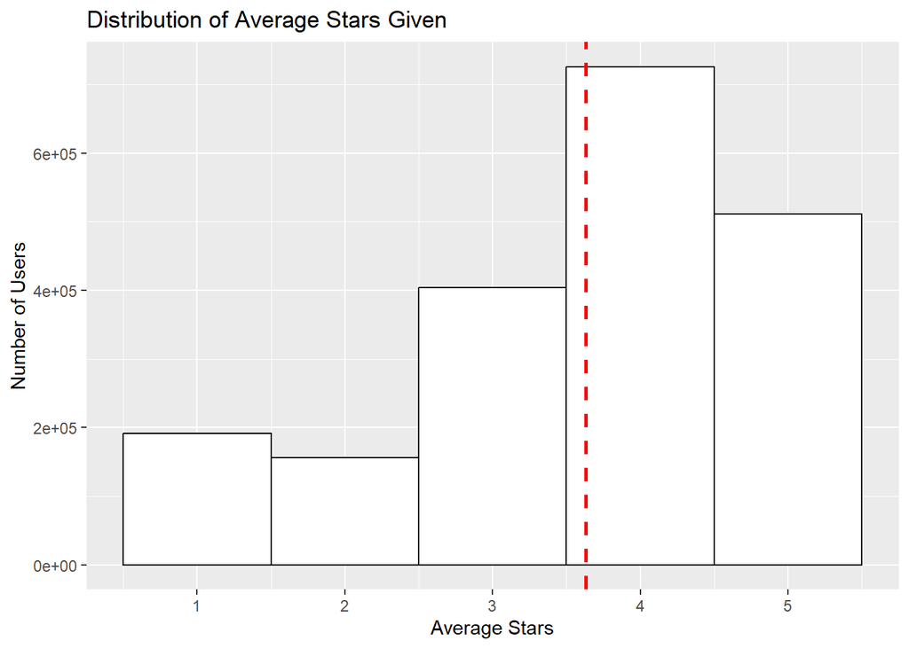

```r
# Average Star Distributions
ggplot(users_cleaned, aes(x=average_stars)) +
  geom_histogram(binwidth = 1, color="black", fill="white") +
  geom_vline(aes(xintercept=mean(average_stars)),
            color="red", linetype="dashed", size=1) +
  labs(title="Distribution of Average Stars Given", x="Average Stars", y="Number of Users")
```

This graph shows the distribution of average stars given across users in the Yelp platform. The red line indicates the mean number of stars.

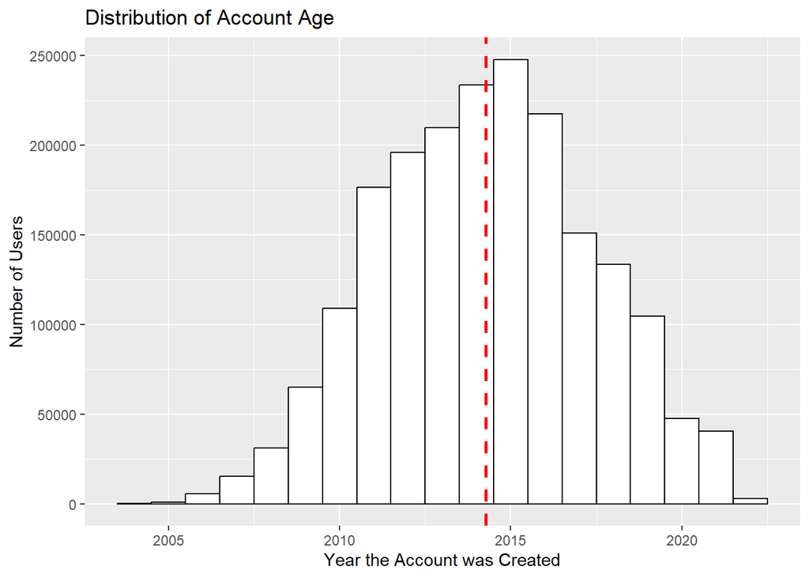

```r
# Distribution of User Profile Ages
ggplot(users_cleaned, aes(x=year_created)) +
  geom_histogram(binwidth = 1, color="black", fill="white") +
  geom_vline(aes(xintercept=mean(year_created)),
            color="red", linetype="dashed", size=1) +
  labs(title="Distribution of Account Age", x="Year the Account was Created", y="Number of Users")
```

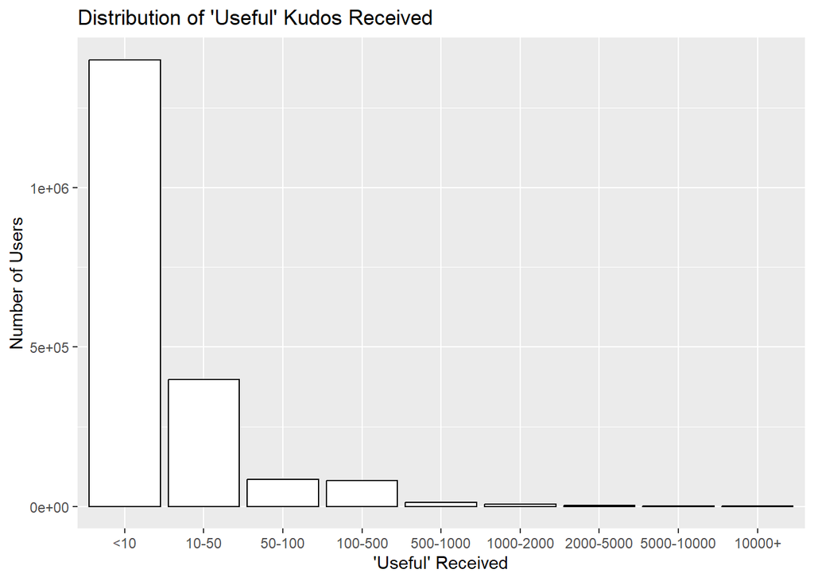

```r
# Histogram of useful reviews
ggplot(users_cleaned, aes(x = useful_count_group)) +
  geom_bar(color="black", fill="white") +
  labs(title="Distribution of 'Useful' Kudos Received", x="'Useful' Received", y="Number of Users")
```

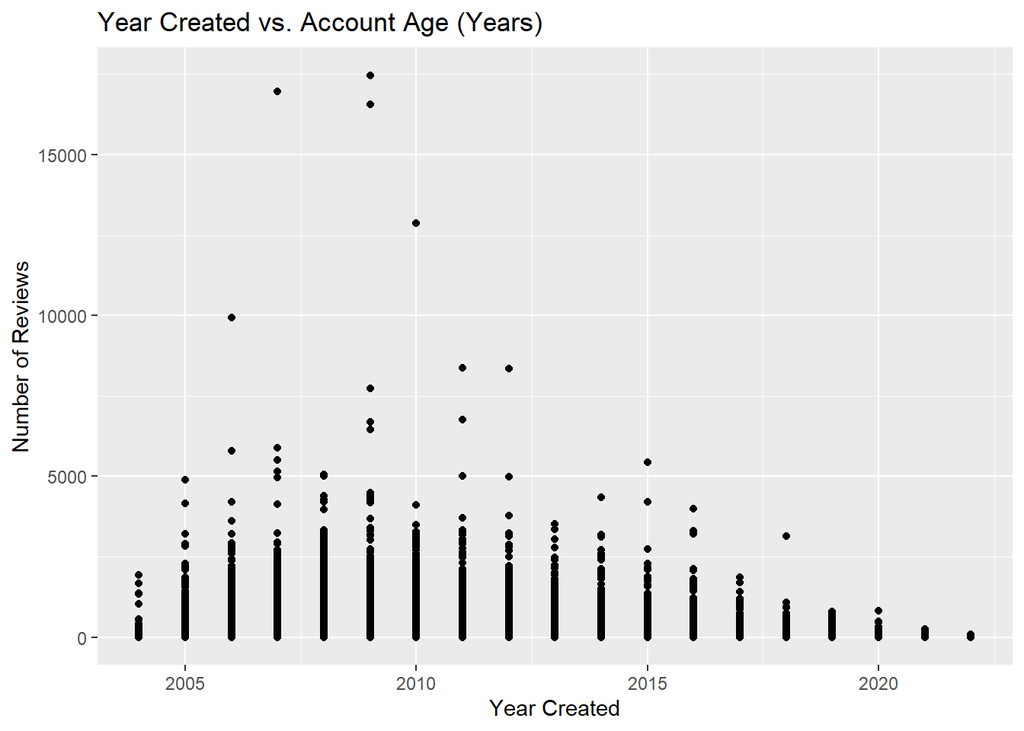

```r
# Scatterplot of review count vs account age (year)
ggplot(users_cleaned, aes(x=year_created, y=review_count)) +
  geom_point() +
  labs(title="Year Created vs. Account Age (Years)", x="Year Created", y="Number of Reviews")
```

This graph shows the relationship between how many reviews a user has written, versus how old their account is. Older accounts are likely to have written more reviews, as expected.

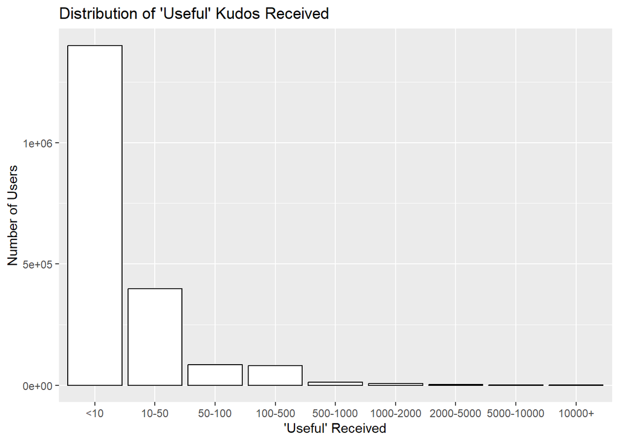

```r
# Histogram of useful reviews
ggplot(users_cleaned, aes(x = useful_count_group)) +
  geom_bar(color="black", fill="white") +
  labs(title="Distribution of 'Useful' Kudos Received", x="'Useful' Received", y="Number of Users")
```

This graph shows the distribution of “useful” kudos received.

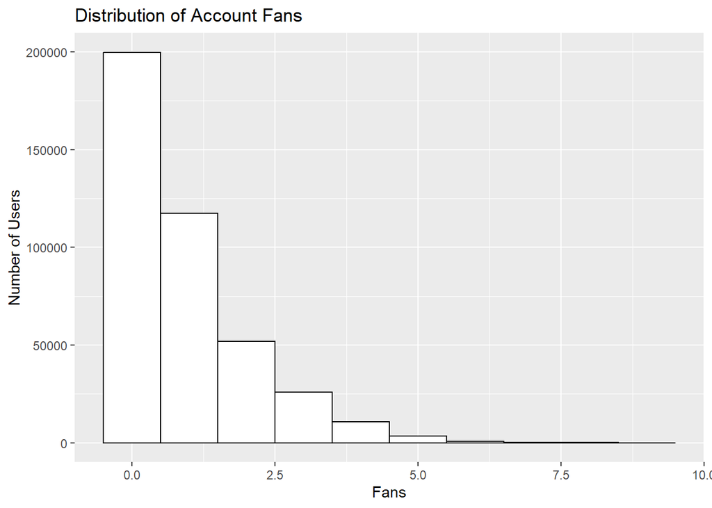

```r
# Histograms of fans
ggplot(users_cleaned, aes(x = log(fans))) +
  geom_histogram(binwidth = 1, color="black", fill="white") +
  labs(title="Distribution of Account Fans", x="Fans", y="Number of Users")
```

This graph shows the distribution of fans that user profiles have. Fans count was log transformed to better visualize the distribution.

### Restaurant visualizations

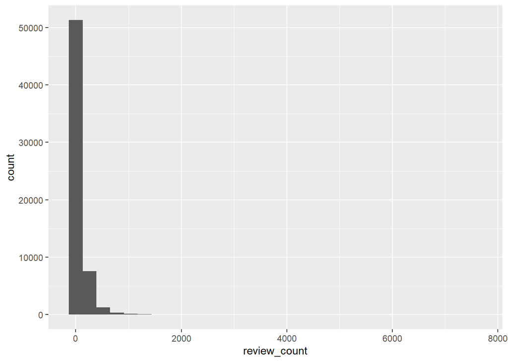

```r
# Distribution of number of reviews
ggplot(restaurants_only, aes(x=review_count)) +
  geom_histogram()
```

This graph shows the distribution in the number of reviews restaurants tend to receive. Restaurants with higher number of reviews tend to also have a higher average star rating. This makes sense intuitively because if a restaurant is good, then it would attract others to visit that restaurant as well.

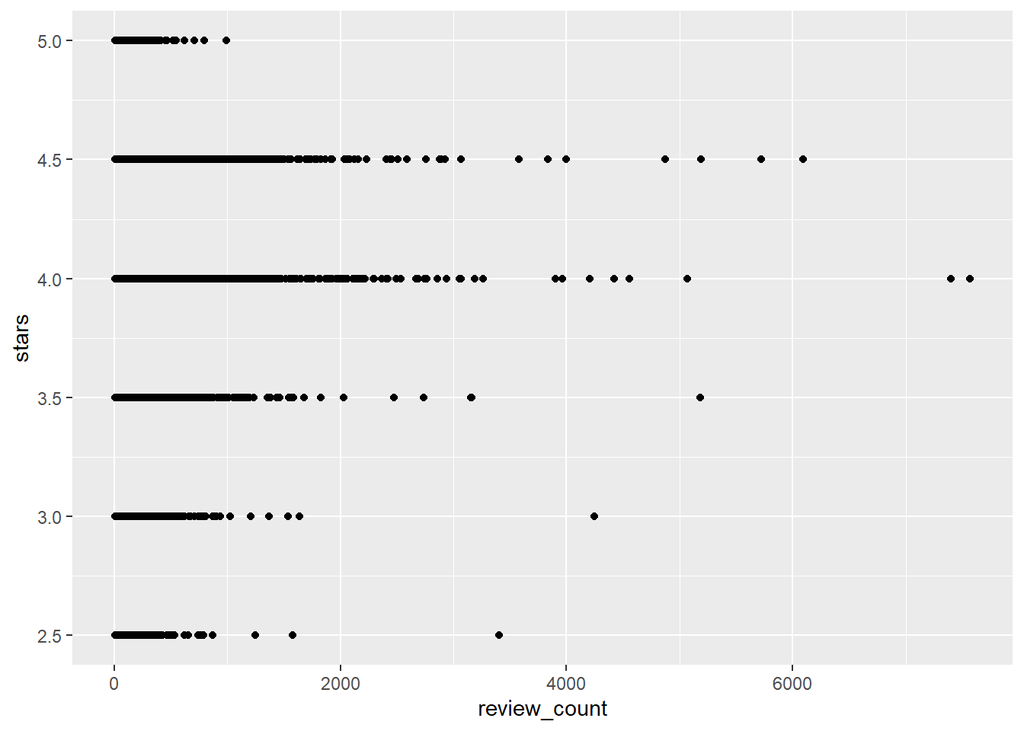

```r
# Review count vs rating scatter plot
ggplot(restaurants_only, aes(x=review_count, y=stars)) +
  geom_point()
```

This graph compares the average stars of a restaurant versus how many reviews they received.

### Review visualizations

```r
#cleaning data
restaurant_reviews <- restaurant_reviews %>%
  mutate(review_year = as.numeric(substr(date, 1, 4))) %>%
  mutate(review_month = as.numeric(substr(date, 6, 7))) %>%
  rename(stars = stars.x) %>%
  select(-c(date, review_count)) %>%
  mutate(review_month = month.name[review_month]) %>%
  mutate(over_3_stars = ifelse(stars>=3, "Yes", "No")) #1 for yes, 0 for no
```

We cleaned the review data by splitting up the date string into year and month separately, as well as grouping reviews into those with more than 3 stars, and those with less than 3 stars.

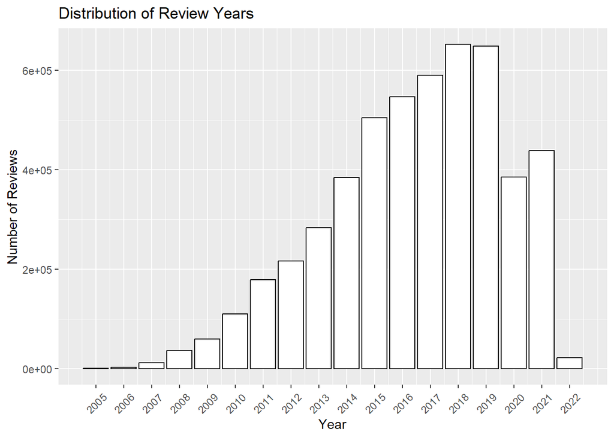

```r
# distribution of reviews given by year
ggplot(restaurant_reviews, aes(x=review_year)) +
  geom_bar(color="black", fill="white") +
  labs(title="Distribution of Review Years", x="Year", y="Number of Reviews") +
  theme(axis.text.x = element_text(angle = 45, vjust = 0.5)) +
  scale_x_continuous(breaks=seq(2005,2022,1))
```

This graphs shows when reviews were published by year, showing both the popularity of the app, as well as the popularity of eating out over the past 20 years. Interestingly, there is a massive decrease from the year 2019 to 2020 in reviews, likely due to the COVID-19 pandemic.

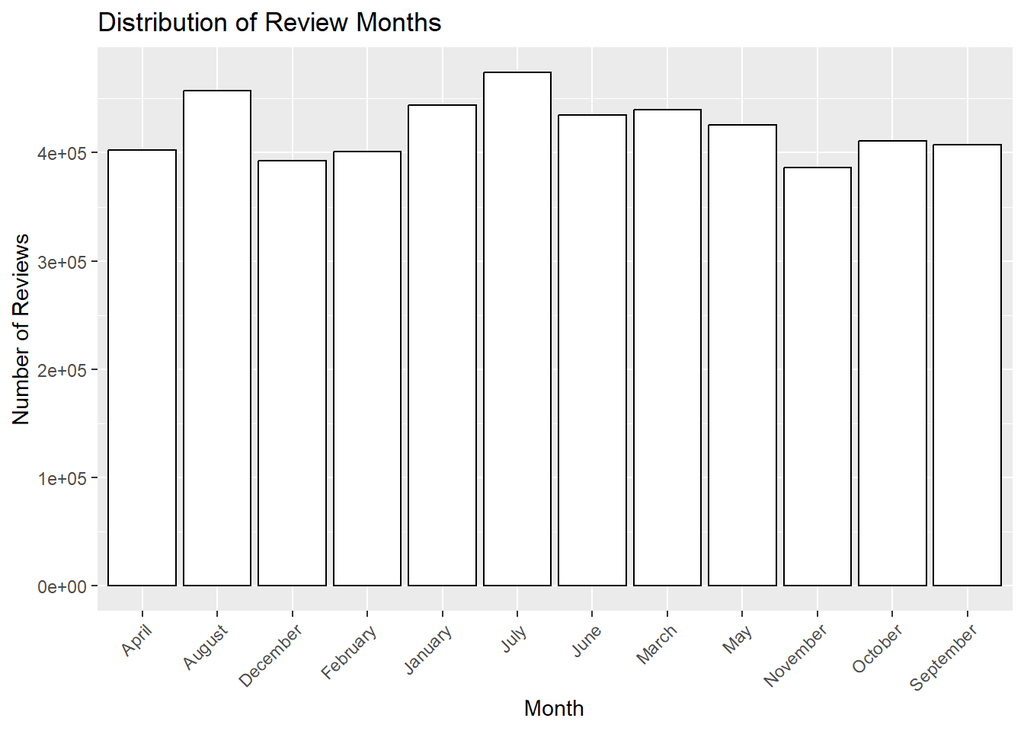

```r
# distribution of reviews given by month
ggplot(restaurant_reviews, aes(x=review_month)) +
  geom_bar(color="black", fill="white") +
  labs(title="Distribution of Review Months", x="Month", y="Number of Reviews") +
  theme(axis.text.x = element_text(angle = 45, hjust = 1))
```

This graph shows when reviews were written by month. This would show if there are any seasonal patterns to when users eat out at restaurants more often.

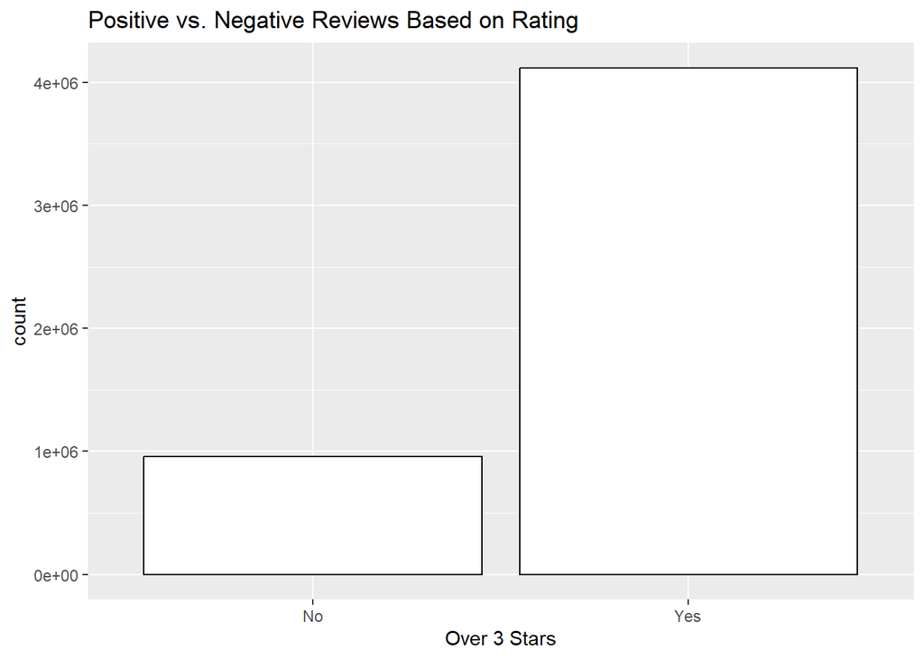

```r
# Positive vs negative reviews (over 3 stars)
ggplot(restaurant_reviews, aes(x=over_3_stars)) +
  geom_bar(color="black", fill="white") +
  labs(title="Positive vs. Negative Reviews Based on Rating", x="Over 3 Stars", "Number of Reviews")
```

This graph compares the number of positive reviews are on the app, versus negative reviews. Users tend to only review restaurants they have a positive experience at.

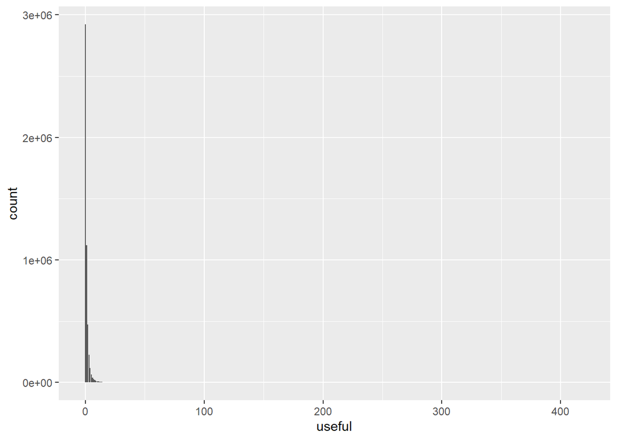

```r
# Distribution of useful reviews
ggplot(restaurant_reviews, aes(x=useful)) +
  geom_bar()
```

This graph shows the distribution of reviews that were given “useful” kudos.

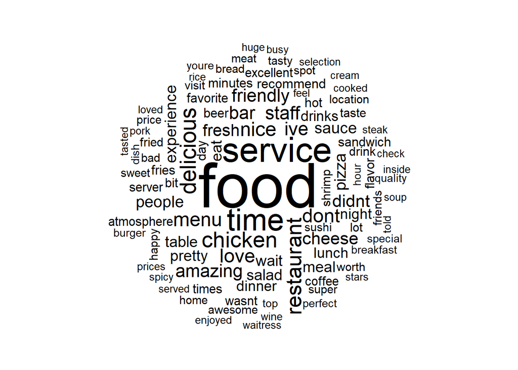

```r
# word cloud of most common words in reviews
# take sample
review_sample <- restaurant_reviews %>%
  sample_n(size = 10000, replace=FALSE)

# Clean the reviews
review_sample$text <- review_sample$text %>%
  str_remove_all('\'') %>%
  str_replace_all("([a-z])([A-Z])", "\\1 \\2") %>%
  tolower() %>%
  str_replace_all("\\s+", " ")
restaurant_reviews_tokenized <- review_sample %>%
  unnest_tokens(word, text) %>%
  anti_join(stop_words)

wordcloud(restaurant_reviews_tokenized$word,
        , scale=c(5,0.5)     # Set min and max scale
        , max.words=100      # Set top n words
        , random.order=FALSE)
```

This is a word cloud of common words found in all restaurant reviews. To prepare the data for word clouds, we took a random sample of reviews, cleaned the strings, and then tokenized the reviews by word.

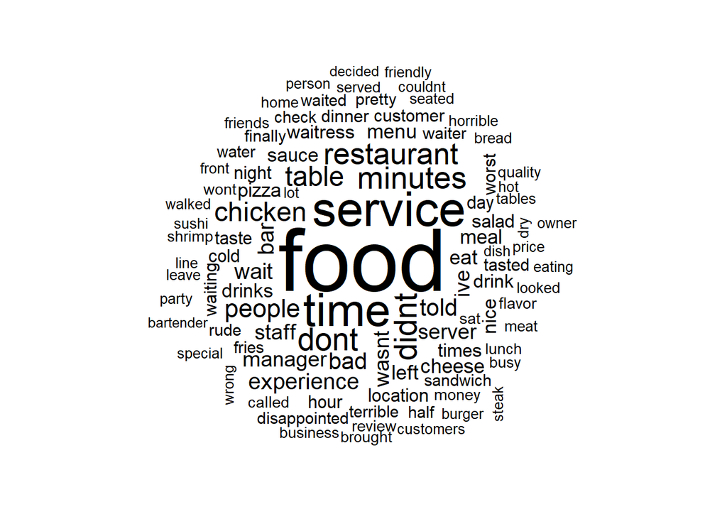

```r
# word cloud of most common words in reviews for under 3 stars
restaurant_reviews_tokenized_neg <- restaurant_reviews_tokenized %>%
  filter(over_3_stars == "No")

wordcloud(restaurant_reviews_tokenized_neg$word,
        , scale=c(5,0.5)     # Set min and max scale
        , max.words=100      # Set top n words
        , random.order=FALSE)
```

Since three stars is typically the cutoff between a good dining experience and a mediocre/bad one, the reviews for restaurants that got less than 3 stars are likely to have different common words than those that users enjoyed eating at.

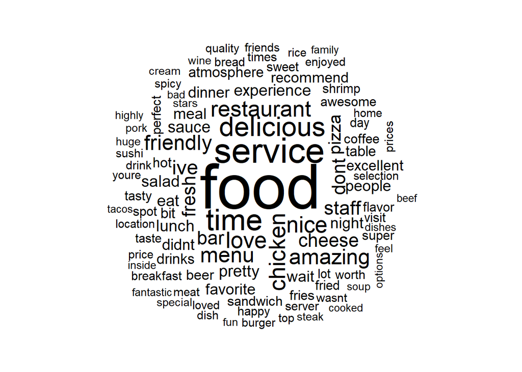

```r
#word cloud of most common words in reviews for over 3 stars
restaurant_reviews_tokenized_pos <- restaurant_reviews_tokenized %>%
  filter(over_3_stars == "Yes")

wordcloud(restaurant_reviews_tokenized_pos$word,
        , scale=c(5,0.5)     # Set min and max scale
        , max.words=100      # Set top n words
        , random.order=FALSE)
```

This is a word cloud of common words in positive reviews.

# Methods

## Natural Language Processing

To enhance the accuracy of our Yelp recommender system, we integrated Natural Language Processing (NLP) techniques to analyze user-written restaurant reviews. Traditional recommendation systems rely on numerical ratings and collaborative filtering; however, by incorporating sentiment analysis, we leveraged qualitative user feedback to refine our model and provide more personalized recommendations.

Using the AFINN sentiment lexicon, we assigned sentiment scores to individual words in restaurant reviews. Our preprocessing steps included filtering the dataset to include California restaurants with at least 100 reviews, a 3-star minimum rating, and active business status. The review text was tokenized, stop words were removed, and sentiment scores were computed by summing the values of sentiment-bearing words in each review. A higher score indicated positive sentiment, while a lower score suggested negative sentiment.

These sentiment scores were then integrated into our collaborative filtering model to adjust recommendation rankings. Restaurants with similar ratings and user interactions were further differentiated by sentiment scores, ensuring that businesses with consistently positive customer sentiment were prioritized. This hybrid approach enhances the accuracy and relevance of our recommendations by combining structured (ratings, user interactions) and unstructured (text reviews) data. The result is a more comprehensive and user-centric recommendation system that better aligns with real-world customer experiences.

```r
business_data <- readRDS("business_data.rds")
review_data <- readRDS("review_data.rds")
```

```r
#get_sentiments("afinn")
afinn <- get_sentiments("afinn")
data("stop_words")
```

### Lexicon

```r
# Filter businesses to include only those in California with:
#   - at least 100 reviews
#   - a star rating of at least 3
#   - that are currently open
#   - whose categories contain the string "Restaurants"
filtered_businesses_CA <- business_data %>%
    filter(
    review_count >= 100,
    stars >= 3,
    is_open == 1,
    state == 'CA',
    sapply(categories, function(x) any(grepl("Restaurants", x)))
  ) %>%
  select(business_id, state, review_count,stars,is_open,categories)

review_data_cleaned_CA <- review_data %>%
  select(review_id, user_id, business_id, text, stars, useful) %>%
  drop_na() %>%
  semi_join(filtered_businesses_CA, by = "business_id")
```

```r
# Clean the text in reviews.
# Here, we remove digits and symbols, remove punctuation (except apostrophes), insert a space between lower and uppercase letters, convert to lowercase, and normalize whitespace.

review_data_filtered_CA <- review_data_cleaned_CA
review_data_filtered_CA$text <- review_data_filtered_CA$text %>%
#  str_replace_all(pattern = "\n", " ") %>%
  str_remove_all('[[:digit:]]') %>%
  str_remove_all('[[:symbol:]]') %>%
  str_replace_all("[[:punct:]&&[^']]", " ") %>%
  str_replace_all("([a-z])([A-Z])", "\\1 \\2")  %>%
  tolower() %>%
  str_replace_all("\\s+", " ")
```

```r
# Generate a table of common words/bigrams across all cleaned reviews in CA for lexicon.
# Tokenize the text, remove stop words, and count frequency.

common_words <- review_data_filtered_CA %>%
  unnest_tokens(word, text) %>%
  anti_join(stop_words) %>%
#  inner_join(afinn) %>%
  count(word, sort = TRUE)

common_bigrams <- review_data_filtered_CA %>%
  unnest_tokens(bigram, text, token = "ngrams", n = 2) %>%
  separate(bigram, c("word1", "word2"), sep = " ") %>%
  filter(!word1 %in% stop_words$word) %>%
  filter(!word2 %in% stop_words$word) %>%
  unite(bigram, word1, word2, sep = " ") %>%
  count(bigram, sort = TRUE)

# write.csv(common_bigrams, "common_bigrams.csv")
```

```r
# Define domain-specific lexicons manually.

price_terms <- c("price", "prices", "expensive", "priced", "pricey", "cheap", "generous", "affordable")

service_terms <- c("service", "staff", "server", "served", "customer", "waiter", "waitress", "fast",
                   "owner", "manager", "customers", "quickly", "servers", "rude", "employees",
                   "serving", "welcoming", "waiters", "workers", "owners", "friendly staff",
                   "super friendly", "friendly service", "wait time")

atmosphere_terms <- c("atmosphere", "ambiance", "ambience", "comfortable", "feeling", "romantic",
                      "environment", "mood", "quiet")
```

### Actual Work

```r
# Extract trigrams from the cleaned review text.
# Tokenize the text into trigrams and then separate each trigram into three words.
# Remove trigrams where any of the three words are stop words.
review_data_trigrams <- review_data_filtered_CA %>%
  unnest_tokens(trigram, text, token = "ngrams", n = 3) %>%
  separate(trigram, into = c("word1", "word2", "word3"), sep = " ") %>%
  filter(!word1 %in% stop_words$word) %>%
  filter(!word2 %in% stop_words$word) %>%
  filter(!word3 %in% stop_words$word)
```

```r
# Filter the trigrams to create domain-specific subsets.
# For each domain, filter for trigrams where the middle word belongs to the respective lexicon.

price_trigrams <- review_data_trigrams %>%
  filter(word2 %in% price_terms)

service_trigrams <- review_data_trigrams %>%
  filter(word2 %in% service_terms)

atmosphere_trigrams <- review_data_trigrams %>%
  filter(word2 %in% atmosphere_terms)
```

```r
# Obtain review counts per business from the original cleaned review dataset.
# Each business_id gets a unique count of reviews.

review_counts <- review_data_filtered_CA %>%
  group_by(business_id) %>%
  summarize(review_count = n(), .groups = "drop")
```

```r
# For each trigrams, group by review_id and trigram components and then count occurrences.

weighted_price <- price_trigrams %>%
  group_by(review_id, word1, word2, word3, useful) %>%
  reframe(counts = n(), across(everything())) %>%
  ungroup() %>%
  mutate(scaling_factor = 1 + log(useful + 1),   # Apply a scaling factor based on 'useful' (likes) using a logarithmic transformation.
         weighted_count = counts * scaling_factor)

# Join with the AFINN lexicon for each word in the trigram to obtain sentiment scores.
# Replace missing sentiment scores with 0, then compute the average sentiment for the trigram.
# Multiply the average sentiment by the weighted count to get a weighted sentiment score.

price_sentiment <- weighted_price %>%
  left_join(afinn, by = c("word1" = "word")) %>%
  rename(score1 = value) %>%
  left_join(afinn, by = c("word2" = "word")) %>%
  rename(score2 = value) %>%
  left_join(afinn, by = c("word3" = "word")) %>%
  rename(score3 = value) %>%
  mutate(score1 = if_else(is.na(score1), 0, score1),
         score2 = if_else(is.na(score2), 0, score2),
         score3 = if_else(is.na(score3), 0, score3),
         avg_score = (score1 + score2 + score3) / 3,
         weighted_score = avg_score * weighted_count)


# Join with review counts and compute the final price domain score for each business.
# Normalize the aggregated score by dividing by sqrt(review_count + 1) to dampen the influence of many reviews.

price_domain_scores <- price_sentiment %>%
  left_join(review_counts, by = "business_id") %>%
  group_by(business_id) %>%
  reframe(price_score = sum(weighted_score) / sqrt(first(review_count) + 1)) %>%
  mutate(price_score = round(price_score, 3))
```

```r
weighted_service <- service_trigrams %>%
  group_by(review_id, word1, word2, word3, useful) %>%
  reframe(counts = n(), across(everything())) %>%
  ungroup() %>%
  mutate(scaling_factor = 1 + log(useful + 1),
         weighted_count = counts * scaling_factor)

service_sentiment <- weighted_service %>%
  left_join(afinn, by = c("word1" = "word")) %>%
  rename(score1 = value) %>%
  left_join(afinn, by = c("word2" = "word")) %>%
  rename(score2 = value) %>%
  left_join(afinn, by = c("word3" = "word")) %>%
  rename(score3 = value) %>%
  mutate(score1 = if_else(is.na(score1), 0, score1),
         score2 = if_else(is.na(score2), 0, score2),
         score3 = if_else(is.na(score3), 0, score3),
         avg_score = (score1 + score2 + score3) / 3,
         weighted_score = avg_score * weighted_count)

service_domain_scores <- service_sentiment %>%
  left_join(review_counts, by = "business_id") %>%
  group_by(business_id) %>%
  reframe(service_score = sum(weighted_score)/ sqrt(first(review_count) + 1)) %>%
  mutate(service_score = round(service_score, 3))
```

```r
weighted_atmosphere <- atmosphere_trigrams %>%
  group_by(review_id, word1, word2, word3, useful) %>%
  reframe(counts = n(), across(everything())) %>%
  ungroup() %>%
  mutate(scaling_factor = 1 + log(useful + 1),
         weighted_count = counts * scaling_factor)

atmosphere_sentiment <- weighted_atmosphere %>%
  left_join(afinn, by = c("word1" = "word")) %>%
  rename(score1 = value) %>%
  left_join(afinn, by = c("word2" = "word")) %>%
  rename(score2 = value) %>%
  left_join(afinn, by = c("word3" = "word")) %>%
  rename(score3 = value) %>%
  mutate(score1 = if_else(is.na(score1), 0, score1),
         score2 = if_else(is.na(score2), 0, score2),
         score3 = if_else(is.na(score3), 0, score3),
         avg_score = (score1 + score2 + score3) / 3,
         weighted_score = avg_score * weighted_count)

atmosphere_domain_scores <- atmosphere_sentiment %>%
  left_join(review_counts, by = "business_id") %>%
  group_by(business_id) %>%
  reframe(atmosphere_score = sum(weighted_score)/ sqrt(first(review_count) + 1)) %>%
  mutate(atmosphere_score = round(atmosphere_score, 3))
```

```r
# Compute the overall sentiment score for each business from all words in the cleaned reviews.

overall_sentiment <- review_data_filtered_CA %>%
  unnest_tokens(word, text) %>%
  left_join(afinn, by = "word") %>%
  mutate(value = if_else(is.na(value), 0, value)) %>%
  count(business_id, word, value, sort = TRUE) %>%
  bind_tf_idf(word, business_id, n) %>%
  group_by(business_id) %>%
  reframe(
    weighted_sentiment = sum(value * tf_idf) / sum(tf_idf)
  ) %>%
  mutate(weighted_sentiment = round(weighted_sentiment, 3))
```

```r
# Join overall sentiment with each domain's scores (price, service, and atmosphere).

final_scores <- overall_sentiment %>%
  left_join(price_domain_scores, by = "business_id") %>%
  left_join(service_domain_scores, by = "business_id") %>%
  left_join(atmosphere_domain_scores, by = "business_id") %>%
  mutate(across(where(is.numeric), ~ replace_na(.x, 0)))
```

```r
write.csv(final_scores, "final_scores.csv")
```

## Recommender System

We move on to our recommender system in Python because of its extensive ecosystem, ease of use, scalability, and industry adoption. What really gives Python the advantage is the fact that it can feasibly perform complicated operations on large data frames, which is needed for this kind of project.